# LDA for Red Knots captured in Nome and Grays Harbor

The means of bringing in data sources and cleaning up the will be different between projects, so this step is glossed over. We are bringing in the all the Red Knots captured in Nome, all the Red Knots captured on Wrangel Island, all the Red Knots captured in Grays Harbor, and subsetting out birds from Grays Harbor that were tracked to Alaska and those tracked to Wrangel Island.

First, Lets investigate differences between our Alaska breeding Knots and our Wrangel Island breeding knots. Unfortuantly, we are gong to be dealing with biased and small sample sizes with birds from Wrangel Island. Comparing males, we can visually investiage the differences between each data source in each measurement with boxplots.

First we can look at the differences with males.

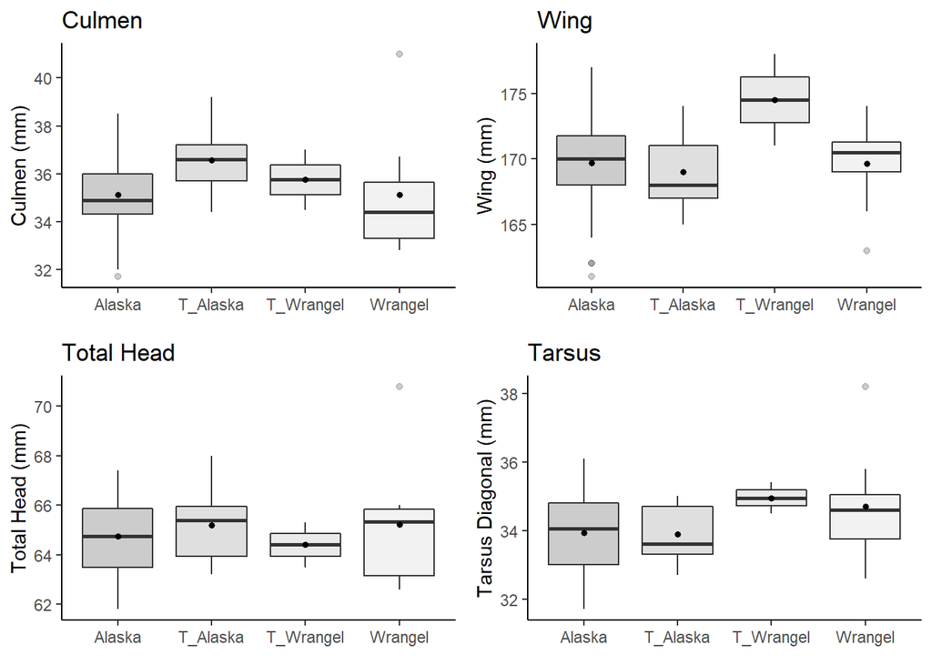

Here we can see lots of overlap. T_Alaska and T_Wrangel represent birds that were tracked using satellite tags from Grays Harbor to those respective breeding grounds. Alaska males n = 70, Wrangel males n = 8, males tracked to Alaska n = 7, males tracked to Wrangel n = 2.

Next, we can look at the differences with females.

[output not shown]

Final dataframe to be working with should look something like this when all data sources are combined. CHDSex is the known molecular sex, culmen, totalHead, tarsus diagonal, and Wing are morphometric measurements collected from all individuals. Nares-to-tip was also measured, but only in a subset of years. Mass was collected, but I elected to not include it given so many variables in REKN that influence MASS outside of sex (days at stopover, health, time of year). Variables will depend on what morphometric measurements were collected for the species.

```
##    CHDSex Culmen TotalHead TarsusDiagonal Wing
## 8       M   34.5      65.1           35.4  171
## 10      M   33.0      62.5           34.6  170
## 11      F   38.0      67.9           35.8  176
## 15      M   31.7      62.9           34.2  171
## 17      M   35.8      63.5           32.5  165
## 18      M   32.7      64.5           34.9  167
## 19      M   35.5      66.1           36.1  171
## 20      M   35.6      63.9           33.7  169
## 21      F   36.6      66.8           34.9  175
## 22      M   34.5      64.5           32.7  166
```

### Examine the Data

First, visually examine the measurements to look for highly correlated measurements. This can be preformed using package “corrplot”.

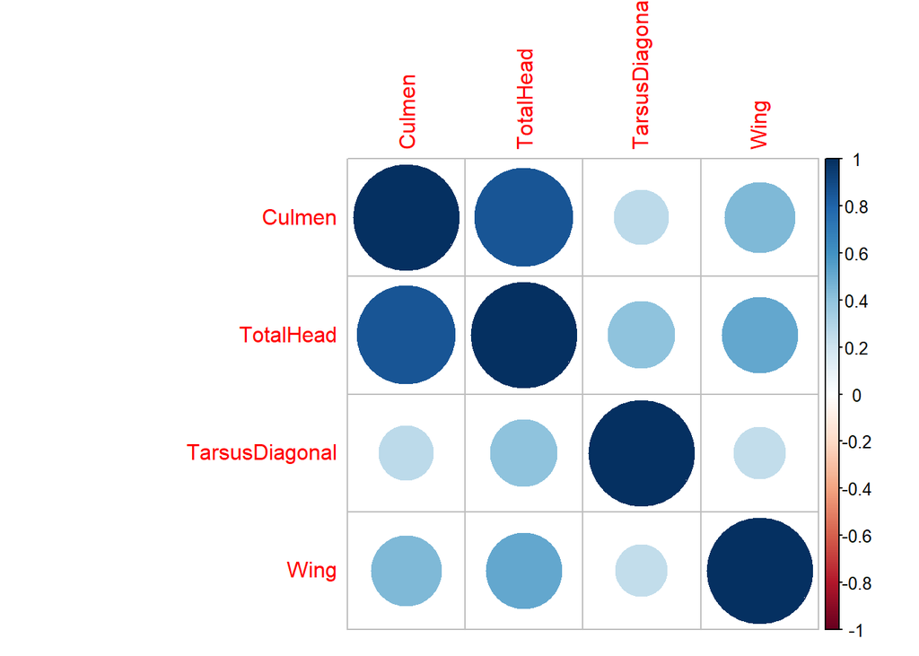

Figure 1. Correlations between morphometric measurements. Larger blue circles indicating high posotive correlation, and large red circles indicating high negative correlation. Here we are seeing all posotive correlations, but culmen and total head having the highest correlation.

```r
library(corrplot)

correlations <- cor(all.rekn[,2:5])
corrplot(correlations, method="circle")
```

Culmen and total head show the highest correlation, and should be used together in a LDA with caution. This makes sense given the culmen measurement is included in the total head measurement. Wing and culmen are also positively correlated, but some positive correlation should be expected. Larger birds will have larger measurements across the board.

It may be helpful to look at density or histograms of measurements between sexes to examine general trends. These can help inform what variables may preform best in the lda.

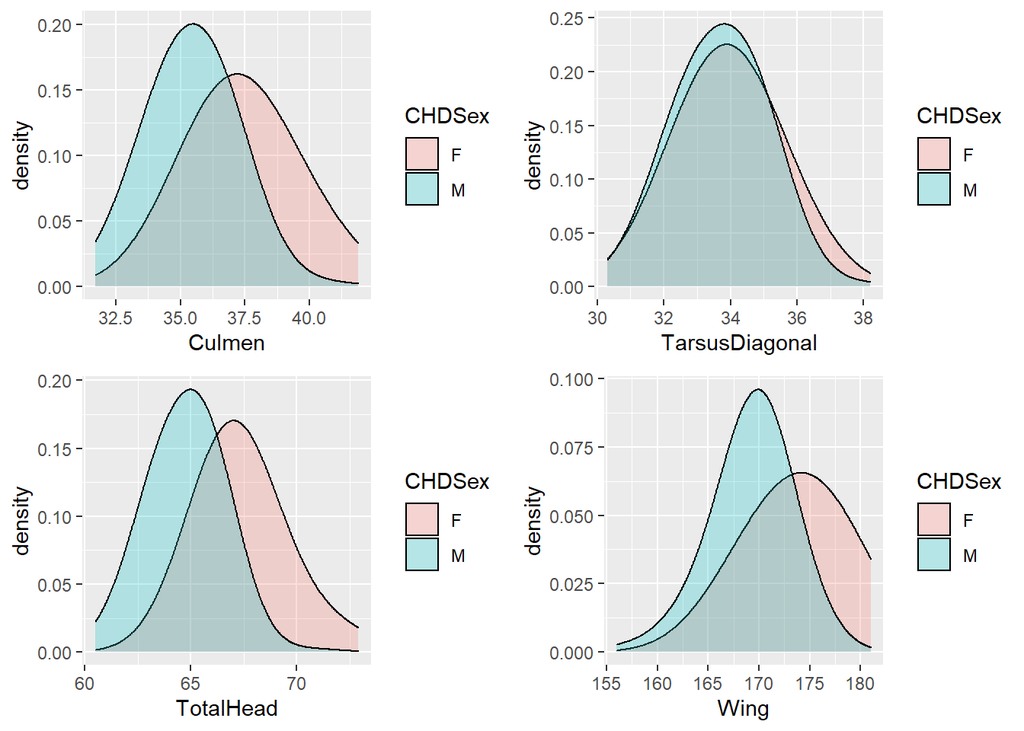

Fiure 2. Density plots of each sexes measurements. Culmen, total head, and wing are the only measurments that show much difference between the two sexes.

```r
library(ggplot2)

ggplot(all.rekn,aes(x=Culmen, fill=CHDSex)) + geom_density(alpha=0.25, adjust = 2.5)
ggplot(all.rekn,aes(x=TotalHead, fill=CHDSex)) + geom_density(alpha=0.25, adjust = 2.5)
ggplot(all.rekn,aes(x=TarsusDiagonal, fill=CHDSex)) + geom_density(alpha=0.25, adjust = 2.5)
ggplot(all.rekn,aes(x=Wing, fill=CHDSex)) + geom_density(alpha=0.25, adjust = 2.5)
```

Box-plots seem to be the tool of choice when displaying these data for publication, so they are included here. These show the same results as the density graphs above.

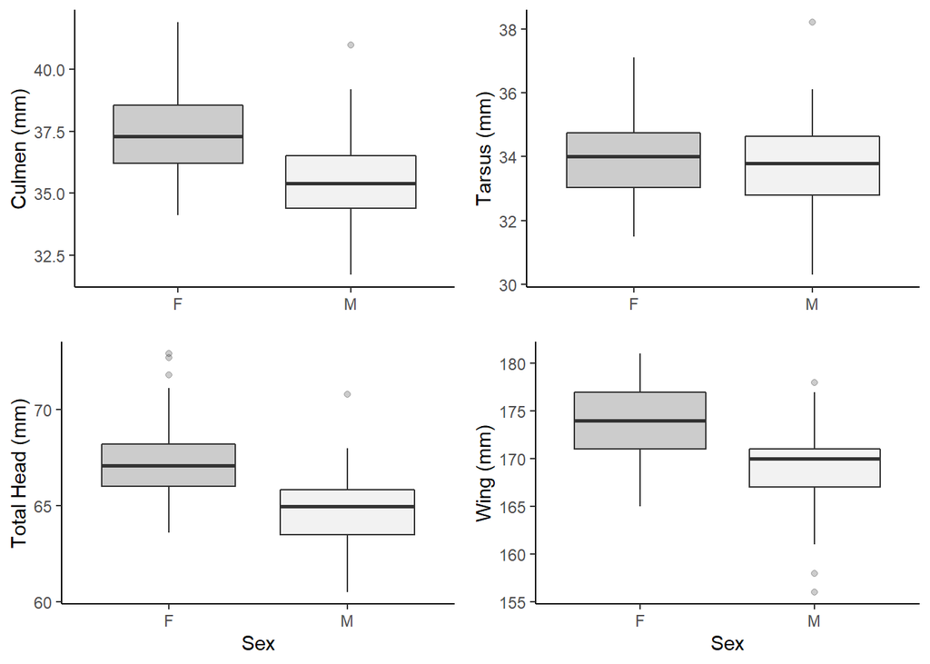

Figure 3. Box-plots depicting the same thing as the density plots earlier. Culmen, total head, and wing are the only measurments that show much difference between the two sexes.

```r
library(ggplot2)

ggplot(all.rekn,aes(y=Culmen, x=CHDSex, fill=CHDSex)) +
      geom_boxplot(alpha=0.25) +
      scale_fill_grey() +
      labs(x=element_blank(), y="Culmen (mm)") +
      theme(panel.background = element_blank(), axis.line = element_line("black"), legend.position = "none")
ggplot(all.rekn,aes(y=TotalHead, x=CHDSex, fill=CHDSex)) +
      geom_boxplot(alpha=0.25) +
      scale_fill_grey() +
      labs(x="Sex", y="Total Head (mm)") +
      theme(panel.background = element_blank(), axis.line = element_line("black"), legend.position = "none")
ggplot(all.rekn,aes(y=TarsusDiagonal, x=CHDSex, fill=CHDSex)) +
      geom_boxplot(alpha=0.25) +
      scale_fill_grey() +
      labs(x=element_blank(),y="Tarsus (mm)") +
      theme(panel.background = element_blank(), axis.line = element_line("black"), legend.position = "none")
ggplot(all.rekn,aes(y=Wing, x=CHDSex, fill=CHDSex)) +
      geom_boxplot(alpha=0.25) +
      scale_fill_grey() +
      labs(x="Sex", y="Wing (mm)") +
      theme(panel.background = element_blank(), axis.line = element_line("black"), legend.position = "none")
```

These graphs show slight differences in average culmen, total head, and wing, with females being larger than males. There is no real separation between sexes in tarsus, and is likely a poor predictor of sex.

LDA can be used with non-normal data, but it preforms better when multinormality is present, especially for classifying unknowns. It might be okay to assume this with large sample sizes and morphometric measurements. The following quantile-quantile plots draw each variable against a normal distribution, and can be used to visually inspect for normality.

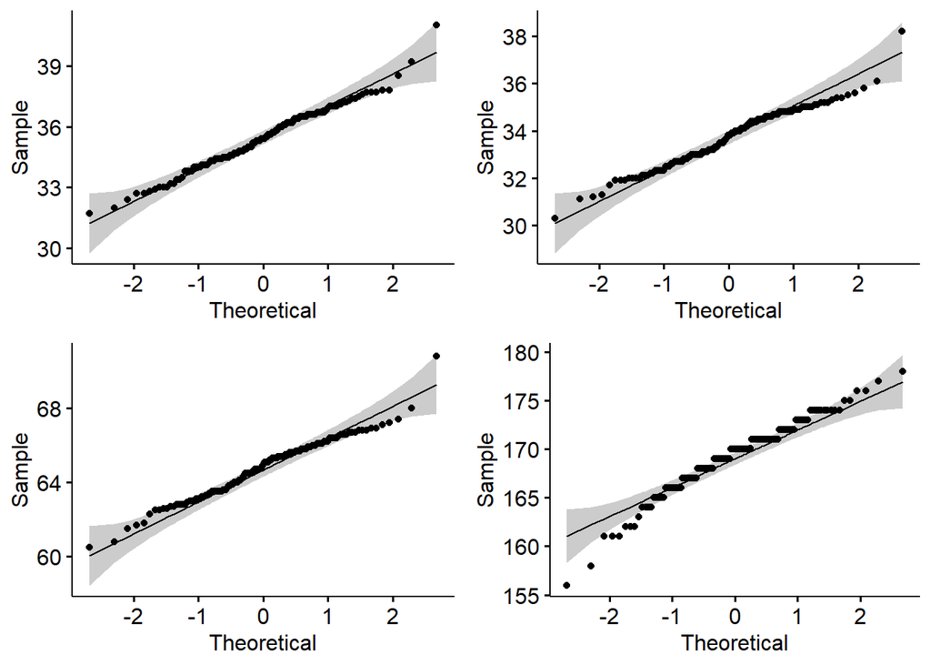

Figure 4. Q-Q plots for all male measurements (Culmen, ToalHead, TarsusDiagonal, and Wing) seeming resonably normal.

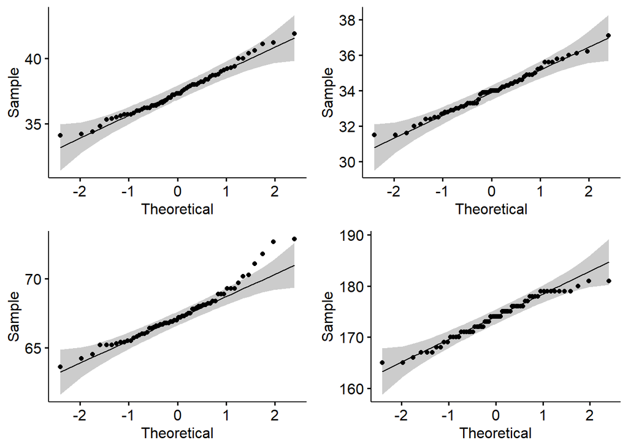

Figure 5. Q-Q plots for all female measurements (Culmen, ToalHead, TarsusDiagonal, and Wing) seeming resonably normal.

```r
library(ggpubr)

#filter groups
all.rekn.m <- all.rekn %>% filter(CHDSex == "M") %>% droplevels
all.rekn.f <- all.rekn %>% filter(CHDSex == "F") %>% droplevels

ggqqplot(all.rekn.m$Culmen)
ggqqplot(all.rekn.m$TotalHead)
ggqqplot(all.rekn.m$TarsusDiagonal)
ggqqplot(all.rekn.m$Wing)

ggqqplot(all.rekn.f$Culmen)
ggqqplot(all.rekn.f$TotalHead)
ggqqplot(all.rekn.f$TarsusDiagonal)
ggqqplot(all.rekn.f$Wing)
```

Some researchers suggest examining data for multidimensional (Mahalanobis) outliers, and removing them. A LDA is very susceptible to outliers, so it should be worth investigating. I do not think this step is necessary with this REKN data set, but it could be something to experiment with in other cases. I will include this step just for future projects and repeatability. This code to remove 1% of the data’s multidimensional outliers. This arbitrary % cutoff seems bizarre to me, but appears to be acceptable in the literature.

```r
percentage.to.remove <- 1 # Remove % of points
number.to.remove <- trunc(nrow(all.rekn) * percentage.to.remove / 100)

#Look for outliers using all measurements
m.dist <- mahalanobis(all.rekn[, 2:5], colMeans(all.rekn[, 2:5]), cov(all.rekn[, 2:5]))
m.dist.order <- order(m.dist, decreasing=TRUE)
rows.to.keep.index <- m.dist.order[(number.to.remove+1):nrow(all.rekn[, 2:5])]
#remove the top 2% of outliers
all.rekn.outliers.out <- all.rekn[rows.to.keep.index,]
```

LDA assumes homogeneity of the variance–covariance matrices. Testing for this can be done using boxM in package “heplots”. These data align with that assumption with a p-value >0.05.

```r
library(heplots)
boxM(all.rekn[2:5],all.rekn$CHDSex)
```

```
##
##  Box's M-test for Homogeneity of Covariance Matrices
##
## data:  all.rekn[2:5]
## Chi-Sq (approx.) = 9.0825, df = 10, p-value = 0.5243
```

### Find the Best Model

Next, we can run LDA models with different variable combinations to see which is the best predictor of sex. Step-wise variable removal is not suggested as a good method to test model accuracy according to Dechaume-Moncharmont 2011, and examining model from a biological perspective is the suggested method here. However, many people still do this, so I outlined the stepwise procedure first.

```r
library(klaR)
modelstepL <- stepclass(CHDSex ~ ., "lda", direction = "both", data = all.rekn, improvement = 0.001, fold = 189)
```

```
## correctness rate: 0.82011;  in: "TotalHead";  variables (1): TotalHead
## correctness rate: 0.84921;  in: "Wing";  variables (2): TotalHead, Wing
##
##  hr.elapsed min.elapsed sec.elapsed
##        0.00        0.00        3.68
```

```r
modelstepL
```

```
## method      : lda
## final model : CHDSex ~ TotalHead + Wing
## <environment: 0x0000000018689628>
##
## correctness rate = 0.8492
```

The non-stepwise procedure involves picking the features that biologically make sense. By using CV=TRUE, we are using the leave-one-out cross-validation method to determine a models predictive accuracy. One individual is removed from the data, the a LDA is calculated with the remaining individuals. This $n-1$ model is then used to predict the sex of removed individual. This is repeated for each individual in the data set. These models do not over-estimate accuracy like the resubstitution method, as each individuals measurements are not included the model to predict itself. This is the preferred method for testing accuracy over of sample-splitting and resubstitution and can be done using lda() from package “MASS”

```r
library(MASS)

#lda using all variables
jacknife1 <- lda(CHDSex~.,data = all.rekn, CV = TRUE)
#lda using culmen, wing, and tarsus
jacknife2 <- lda(CHDSex~ Culmen + Wing + TarsusDiagonal, data = all.rekn, CV = TRUE)
#lda using culmen, wing, and total head
jacknife3 <- lda(CHDSex~ TotalHead + Wing + TarsusDiagonal, data = all.rekn, CV = TRUE)
#lda using total head and wing
jacknife4 <- lda(CHDSex~ TotalHead + Wing, data = all.rekn, CV = TRUE)
#lda using culmen and wing
jacknife5 <- lda(CHDSex~ Culmen + Wing, data = all.rekn, CV = TRUE)
```

Each model incorporates different morphometric variables. Biologically, we can start to eliminate some combinations. We know models using total head and culmen are not ideal since these values are highly correlated, so we should steer away from them. We know tarsus is likely a poor predictor of sex, but this doesn’t necessarily mean it should be excluded from the models. Of these possible combinations, which accurately predicted the sex of known sexed individuals? Total Head + Wing? Culmen + Wing? Total Head + Wing + Tarsus? Culmen + Wing + Tarsus? Once the models have been run, a table for each models predicted sex and known sex needs to be set up to be run in a confusion matrix.

```r
jacknife1.acc <- table(all.rekn$CHDSex,
                       jacknife1$class, dnn = c("Actual Group", "Predicted Group"))
jacknife2.acc <- table(all.rekn$CHDSex,
                       jacknife2$class, dnn = c("Actual Group", "Predicted Group"))
jacknife3.acc <- table(all.rekn$CHDSex,
                       jacknife3$class, dnn = c("Actual Group", "Predicted Group"))
jacknife4.acc <- table(all.rekn$CHDSex,
                       jacknife4$class, dnn = c("Actual Group", "Predicted Group"))
jacknife5.acc <- table(all.rekn$CHDSex,
                       jacknife5$class, dnn = c("Actual Group", "Predicted Group"))
```

Next, use package “caret” to view the how accurate each model was with confusionmatric().

```r
library(caret)

caret::confusionMatrix(jacknife1.acc)
caret::confusionMatrix(jacknife2.acc)
caret::confusionMatrix(jacknife3.acc)
caret::confusionMatrix(jacknife4.acc)
caret::confusionMatrix(jacknife5.acc)
```

```r
#Total head, wing, and tarsus
cm3
```

```
## Confusion Matrix and Statistics
##
##             Predicted Group
## Actual Group   F   M
##            F  41  21
##            M   9 127
##
##                Accuracy : 0.8485
##                  95% CI : (0.7908, 0.8954)
##     No Information Rate : 0.7475
##     P-Value [Acc > NIR] : 0.0004079
##
##                   Kappa : 0.6282
##
##  Mcnemar's Test P-Value : 0.0446097
##
##             Sensitivity : 0.8200
##             Specificity : 0.8581
##          Pos Pred Value : 0.6613
##          Neg Pred Value : 0.9338
##              Prevalence : 0.2525
##          Detection Rate : 0.2071
##    Detection Prevalence : 0.3131
##       Balanced Accuracy : 0.8391
##
##        'Positive' Class : F
##
```

```r
#Total head, wing
cm4
```

```
## Confusion Matrix and Statistics
##
##             Predicted Group
## Actual Group   F   M
##            F  41  21
##            M   7 129
##
##                Accuracy : 0.8586
##                  95% CI : (0.8021, 0.9039)
##     No Information Rate : 0.7576
##     P-Value [Acc > NIR] : 0.0003291
##
##                   Kappa : 0.6497
##
##  Mcnemar's Test P-Value : 0.0140193
##
##             Sensitivity : 0.8542
##             Specificity : 0.8600
##          Pos Pred Value : 0.6613
##          Neg Pred Value : 0.9485
##              Prevalence : 0.2424
##          Detection Rate : 0.2071
##    Detection Prevalence : 0.3131
##       Balanced Accuracy : 0.8571
##
##        'Positive' Class : F
##
```

```r
cm4$table
```

```
##             Predicted Group
## Actual Group   F   M
##            F  41  21
##            M   7 129
```

```r
print(cm4$overall)
```

```
##       Accuracy          Kappa  AccuracyLower  AccuracyUpper   AccuracyNull
##   0.8585858586   0.6497346475   0.8021417284   0.9039298145   0.7575757576
## AccuracyPValue  McnemarPValue
##   0.0003291164   0.0140192771
```

Now that the best variables have been selected – through the step-wise selection and cross-validated verification, we can go back to see what the model actually looks like. We can go back to our original lda() function using package “MASS” and run it without the CV=TRUE clause and the variables we just identified as being the best predictors (total head and wing) and run it with the entire data set.

```r
#run the lda with Total Head, Wing, and Tarsus as variables
lda4 <- lda(CHDSex~ TotalHead + Wing, data = all.rekn)

lda4
```

```
## Call:
## lda(CHDSex ~ TotalHead + Wing, data = all.rekn)
##
## Prior probabilities of groups:
##         F         M
## 0.3131313 0.6868687
##
## Group means:
##   TotalHead     Wing
## F  67.39032 173.7258
## M  64.76397 169.2654
##
## Coefficients of linear discriminants:
##                  LD1
## TotalHead -0.4617501
## Wing      -0.1090693
```

Extracting the Coefficients of Linear Discriminates from this lda provide the following formula. This formula is what could be used to calculate your individual LD1 values in the field and assign a field sex.

$-0.1090693 Wing - 0.4617501 Total Head$

We then use this model to predict the sexes of the known sexed birds. This allows us to visualize the results of the predictions.

```r
predict4 <- predict(lda4, newdata = all.rekn)

predict4.df <- data.frame(type = all.rekn[,1], lda = predict4$x)
```

We can then plot the LD1 values for each individual. If an individuals LD1 values are larger, there is a higher probability the individual is male, and if an individuals LD1 values are small, there is a higher probability the individual is female. Sex is assigned when probability of group membership is > 0.5. If higher classification accuracies are required, and unknown sex is okay, you can fit a curve to the probability of group membership and only classify sex of individuals with higher probabilities of being that particular sex. For example, only classify birds that have >0.8 probabilty of group memberhsip, and birds <0.8 and >0.5 are left as “unknowns”. This requires finding the LD1 value that corresponds to those more restrictive probabilities.

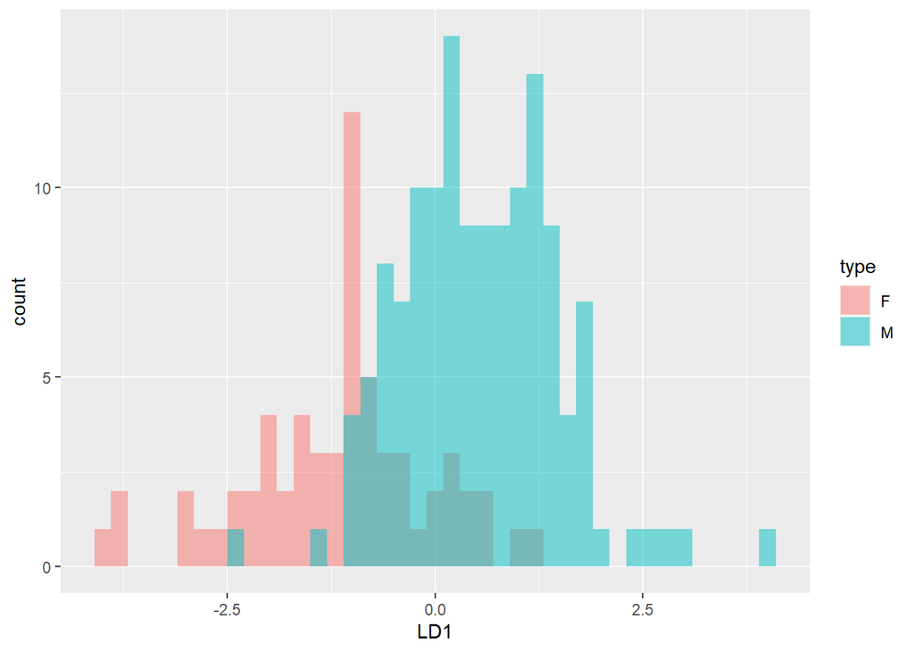

```r
ggplot(predict4.df, aes(LD1, fill = type)) +
  geom_histogram( alpha = .5, position = "identity", binwidth = .2)
```

### Increasing accuracey

We can fit a curve to the probabilty of group membership to calculate new LD1 values that correspond to probabilities >0.5. Here we use 0.8 to seleect birds that have a higher probability of being each sex.

```r
df.resub4.g <- data.frame(all.rekn, predict4$x, predict4$posterior)

names(df.resub4.g)[names(df.resub4.g) == "F"] <- "Prob.F"

df.resub4.g$Prob.Fe <- df.resub4.g$Prob.F + rnorm(length(df.resub4.g$Prob.F), sd = 0.000000005)

fitmodel <- nls( Prob.Fe ~ a/(1 + exp(b * (LD1 + c))), data = df.resub4.g, start=list(a = 1,b = 1.5,c = 0.1))

coef(fitmodel)
```

```
##         a         b         c
## 1.0000000 1.6992071 0.7798151
```

```r
x <- seq(-4,4,.001)
y <- (1 / (1 + exp(1.699207 * (x + 0.7798151))))

testdf <- as.data.frame(cbind(x,y))


cutoffF <- df.resub4.g %>% filter(Prob.F > 0.8)
cutoffM <- df.resub4.g %>% filter(Prob.F < 0.2)
```

This formula gives us the ability to calculate the probability of group membership based on LD1 values. From this we can see restricint the probability of group membership to 0.8 creates new LD1 cutoff values at <-1.6 for Females and >0.035 for males. Values >-1.6 and < 0.035 are left unclassified.

$1 / (1 + exp(1.699207 * (x + 0.7798151)))$

Graph the fitted line and where males and females fall for probability of being female. These more restrictive probabilities correctly sexed 95% of females ($n = 19$) and 90.3% of males ($n = 93$). This left 37.8% ($n = 75$) unclassified.

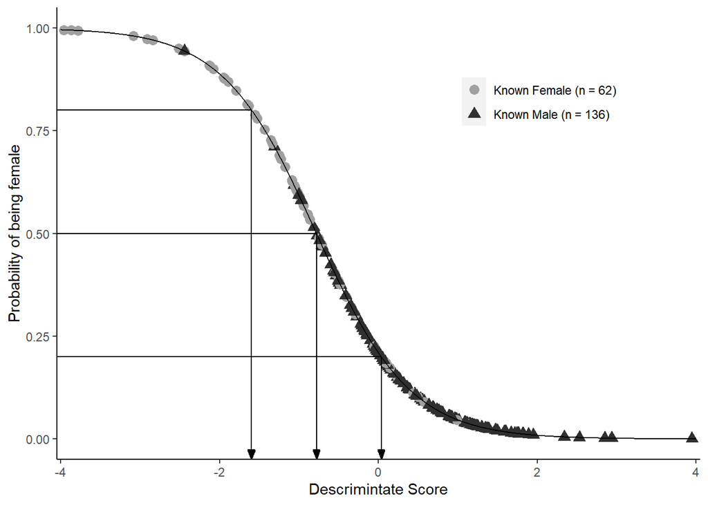

```r
ggplot() +
  geom_point(data = df.resub4.g, aes(x=LD1, y=Prob.F, shape = CHDSex, color = CHDSex), size = 3) +
  scale_color_manual(values=c('#A0A0A0','#303030'), labels = c("Known Female (n = 62)", "Known Male (n = 136)")) +
  scale_shape_manual(values=c(16, 17), labels = c("Known Female (n = 62)", "Known Male (n = 136)")) +
  geom_line(data = testdf, aes(x=x, y=y)) +
  labs(x="Descrimintate Score", y="Probability of being female") +
  theme(panel.background = element_blank(),
        axis.line = element_line("black"),
        legend.position = c(.75,.8),
        legend.title=element_blank()) +
  geom_segment(aes(x = -4.05, y = .8, xend = -1.6, yend = 0.8)) +
  geom_segment(aes(x = -4.05, y = .5, xend = -0.78, yend = 0.5)) +
  geom_segment(aes(x = -4.05, y = .2, xend = 0.035, yend = 0.2)) +
  geom_segment(aes(x = -1.6, y = 0.8, xend = -1.6, yend = -0.05), arrow = arrow(type = "closed", angle = 20, length = unit(.1,"inches"))) +
  geom_segment(aes(x = -0.78, y = 0.5, xend = -0.78, yend = -0.05), arrow = arrow(type = "closed", angle = 20, length = unit(.1,"inches"))) +
  geom_segment(aes(x = 0.035, y = 0.2, xend = 0.035, yend = -0.05), arrow = arrow(type = "closed", angle = 20, length = unit(.1,"inches"))) +
  scale_y_continuous(expand = c(0, 0), limits = c(-0.05, 1.05)) +
  scale_x_continuous(expand = c(0, 0), limits = c(-4.05, 4.05))
```

Replotting LD1 values with the new cutoff scores.

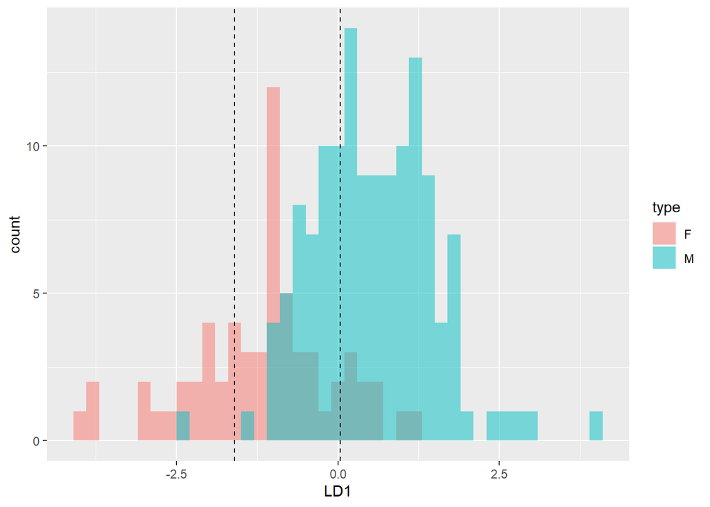

```r
ggplot(predict4.df, aes(LD1, fill = type)) +
  geom_histogram( alpha = .5, position = "identity", binwidth = .2) +
  geom_vline(xintercept = -1.6, linetype="dashed") +
  geom_vline(xintercept = .035, linetype="dashed")
```